# Reproducible Research: Peer Assessment 1

Before begininng the data analysis, we will load packages that will be useful in our analysis.

```r
library(dplyr)
```

```r
library(lubridate)
library(ggplot2)
library(scales)
```

## Loading and preprocessing the data

The data for this assessment is contained in a zip file. We can load the data directly from the zip file using the function `unz()` inside our call to `read.csv()`. We can then create a data frame table with the `tbl_df()` that will make printing simpler.

```r
activity <- read.csv(unz("activity.zip", "activity.csv"),
                     header=TRUE, stringsAsFactors=FALSE)
activity <- tbl_df(activity)
```

Let’s look at the data and check the class of each column to see what we have.

```r
activity
```

```
## Source: local data frame [17,568 x 3]
##
##    steps       date interval
## 1     NA 2012-10-01        0
## 2     NA 2012-10-01        5
## 3     NA 2012-10-01       10
## 4     NA 2012-10-01       15
## 5     NA 2012-10-01       20
## 6     NA 2012-10-01       25
## 7     NA 2012-10-01       30
## 8     NA 2012-10-01       35
## 9     NA 2012-10-01       40
## 10    NA 2012-10-01       45
## ..   ...        ...      ...
```

```r
lapply(activity,class)
```

```
## $steps
## [1] "integer"
##
## $date
## [1] "character"
##
## $interval
## [1] "integer"
```

We have three columns in our data set:

- an integer number of steps measured in a 5 minute interval
- a character string for the date that the measurement was taken in the format *yyyy-mm-dd*
- an integer representing the time in a format *hhmm*

For the moment we will leave the date variable as it is but we would ideally like the time interval to be of the form *hh:mm*. To do this, we need several steps. We first pad the current value with leading zeros using `formatC()` and then convert this to a date time variable with `strptime()`. `strptime()` will append today’s date so the last step is to use `format()` to keep only the time as a string of the form *hh:mm*.

```r
activity$interval <-  activity$interval %>%
                      formatC(width=4,format="d",flag="0") %>%
                      strptime(format="%H%M") %>%
                      format(format="%H:%M")
activity
```

```
## Source: local data frame [17,568 x 3]
##
##    steps       date interval
## 1     NA 2012-10-01    00:00
## 2     NA 2012-10-01    00:05
## 3     NA 2012-10-01    00:10
## 4     NA 2012-10-01    00:15
## 5     NA 2012-10-01    00:20
## 6     NA 2012-10-01    00:25
## 7     NA 2012-10-01    00:30
## 8     NA 2012-10-01    00:35
## 9     NA 2012-10-01    00:40
## 10    NA 2012-10-01    00:45
## ..   ...        ...      ...
```

## What is mean total number of steps taken per day?

The first item we would like to look at is the total number of steps taken per day. For that we simply group our data by date and then sum the number of steps.

```r
by_day <- summarise(group_by(activity, date),total_steps=sum(steps))
by_day
```

```
## Source: local data frame [61 x 2]
##
##          date total_steps
## 1  2012-10-01          NA
## 2  2012-10-02         126
## 3  2012-10-03       11352
## 4  2012-10-04       12116
## 5  2012-10-05       13294
## 6  2012-10-06       15420
## 7  2012-10-07       11015
## 8  2012-10-08          NA
## 9  2012-10-09       12811
## 10 2012-10-10        9900
## ..        ...         ...
```

Note that in taking the sum above, we did not say to remove NA values. The reason for this is that in the dataset there are entire days with no data points and if we say to ignore NA values, the sum of the steps for that day would be zero. A zero could be interpreted as saying that the person stayed in one position and did not take a single step for an entire day. That is quite different from an NA value which says “we don’t know, we don’t have any data”.

Let’s plot a histogram of the total number of steps per day.

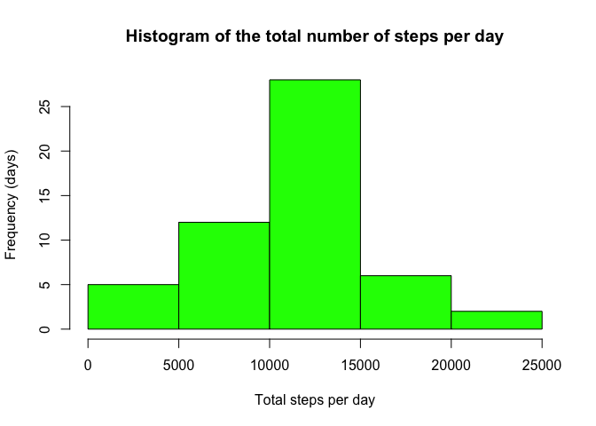

```r
hist (by_day$total_steps,
      main="Histogram of the total number of steps per day",
      xlab="Total steps per day",
      ylab="Frequency (days)",
      col="green")
```

From the above histogram we can say that on average this person took between 10000 and 15000 steps per day. We can find out exactly what that is by finding the mean and the median of the total steps per day.

```r
mean(by_day$total_steps, na.rm=TRUE)
```

```
## [1] 10766.19
```

```r
median(by_day$total_steps, na.rm=TRUE)
```

```
## [1] 10765
```

The mean is only slighlty larger than the median at 10766.19 steps for the mean versus 10765 for the median.

## What is the average daily activity pattern?

To see what the daily activity pattern looks like, we need to group the data by time interval and average the number of steps. We can then convert the interval string to a POSIXct time using `strptime()` and `format()`

```r
by_interval <- summarise(group_by(activity, interval),
                         average_steps = mean(steps, na.rm=TRUE))
by_interval
```

```
## Source: local data frame [288 x 2]
##
##    interval average_steps
## 1     00:00     1.7169811
## 2     00:05     0.3396226
## 3     00:10     0.1320755
## 4     00:15     0.1509434
## 5     00:20     0.0754717
## 6     00:25     2.0943396
## 7     00:30     0.5283019
## 8     00:35     0.8679245
## 9     00:40     0.0000000
## 10    00:45     1.4716981
## ..      ...           ...
```

To plot this and see the pattern, we need to convert the interval string to a POSIXct time.

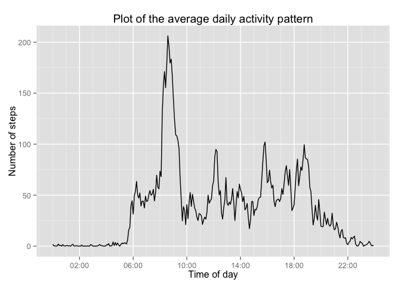

```r
g <- ggplot(by_interval,
            aes(as.POSIXct(interval, format="%H:%M"), average_steps))

g + geom_line() +
    scale_x_datetime(breaks = date_breaks("4 hour"),
                     minor_breaks = date_breaks("1 hour"),
                     labels=date_format("%H:%M")) +
    labs(title = "Plot of the average daily activity pattern") +
    labs(x = "Time of day") +
    labs(y = "Number of steps")
```

We can see in the plot that there is a big peak in activity in the morning, probably as the person is on their way to work or school. To find when that peak occurs, we simply need to filter on the maximum value of *average_steps*.

```r
by_interval %>% filter(average_steps == max(average_steps))
```

```
## Source: local data frame [1 x 2]
##
##   interval average_steps
## 1    08:35      206.1698
```

The peak of activity occurs at 8:35 am where there are approximately 207 steps in that 5 minute interval.

## Imputing missing values

As mentioned previously, there are a number of NA values in the data set. To see exactly how many, we can make an logical vector by passing our number of steps to the `is.na()` function and then summing over the vector.

```r
sum(is.na(activity$steps))
```

```
## [1] 2304
```

If we want to see on what days these occur, we can filter our *by_day* subset according to which days have a *total.steps* value of NA.

```r
by_day %>% filter(is.na(total_steps))
```

```
## Source: local data frame [8 x 2]
##
##         date total_steps
## 1 2012-10-01          NA
## 2 2012-10-08          NA
## 3 2012-11-01          NA
## 4 2012-11-04          NA
## 5 2012-11-09          NA
## 6 2012-11-10          NA
## 7 2012-11-14          NA
## 8 2012-11-30          NA
```

We see that there are 8 days where no data is available. To impute values for these missing measurements, we can group by the interval and then mutate steps using an *ifelse* statement.

```r
activity <- activity %>%
            group_by(interval) %>%
            mutate(steps=ifelse(is.na(steps), mean(steps, na.rm=TRUE), steps))
activity
```

```
## Source: local data frame [17,568 x 3]
## Groups: interval
##
##        steps       date interval
## 1  1.7169811 2012-10-01    00:00
## 2  0.3396226 2012-10-01    00:05
## 3  0.1320755 2012-10-01    00:10
## 4  0.1509434 2012-10-01    00:15
## 5  0.0754717 2012-10-01    00:20
## 6  2.0943396 2012-10-01    00:25
## 7  0.5283019 2012-10-01    00:30
## 8  0.8679245 2012-10-01    00:35
## 9  0.0000000 2012-10-01    00:40
## 10 1.4716981 2012-10-01    00:45
## ..       ...        ...      ...
```

If we look at the first few lines of *activity* we can see that the values of steps that were NA now correspond to the values of average_steps computed in the last section.

To see the impact of imputing the missing data, let’s recompute our *by_day* data frame and plot another histogram of the total number of steps per day.

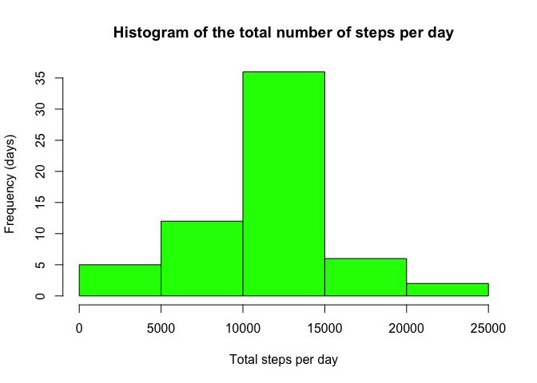

```r
by_day <- summarise(group_by(activity, date),total_steps=sum(steps))
hist (by_day$total_steps,
      main="Histogram of the total number of steps per day",
      xlab="Total steps per day",
      ylab="Frequency (days)",
      col="green")
```

We can see that the form is very similar to our previous result except that the center bar of the histogram for 10000 ~ 15000 steps is now 8 days higher due to the imputed data being based on the mean of the activity.

If we now recompute the *mean* and the *median* of the total number of steps per day, we will see that they are the same.

```r
mean(by_day$total_steps)
```

```
## [1] 10766.19
```

```r
median(by_day$total_steps)
```

```
## [1] 10766.19
```

Whereas previously we had only integer values for the total number of steps per day, by imputing missing values with the average of activity in each interval and then by summing over these, we now have 8 days that have exactly the mean number of steps per day as we previously calculated. As a consequency, the median value concides with this mean.

## Are there differences in activity patterns between weekdays and weekends?

We want to know if there are differences in activity during the weekday compared to the weekend. For that, we will add an extra field that takes on the values of *weekday* and *weekend*.

To determine determine if a date corresponds to a *weekday* or *weekend*, we will use the `wday()` function from lubridate. The `wday()` function numbers the days from 1 to 7 with 1 being Sunday and 7 being Saturday. Therefore, the days numbered 2 through 6 will be classified as weekdays while days 1 and 7 are the weekend.

```r
activity$weekday_weekend <- ifelse((wday(activity$date) > 1) &
                                   (wday(activity$date) < 7),
                                   "weekday", "weekend")
activity
```

```
## Source: local data frame [17,568 x 4]
## Groups: interval
##
##        steps       date interval weekday_weekend
## 1  1.7169811 2012-10-01    00:00         weekday
## 2  0.3396226 2012-10-01    00:05         weekday
## 3  0.1320755 2012-10-01    00:10         weekday
## 4  0.1509434 2012-10-01    00:15         weekday
## 5  0.0754717 2012-10-01    00:20         weekday
## 6  2.0943396 2012-10-01    00:25         weekday
## 7  0.5283019 2012-10-01    00:30         weekday
## 8  0.8679245 2012-10-01    00:35         weekday
## 9  0.0000000 2012-10-01    00:40         weekday
## 10 1.4716981 2012-10-01    00:45         weekday
## ..       ...        ...      ...             ...
```

If we look at the class of our newly created variable we will see that it is a character variable and not a factor as we would like.

```r
class(activity$weekday_weekend)
```

```
## [1] "character"
```

To create a factor variable, we need simply to apply a transform to factor.

```r
activity <- transform(activity, weekday_weekend = factor(weekday_weekend))
class(activity$weekday_weekend)
```

```
## [1] "factor"
```

To see the difference in activity between weekdays and weekends, we want to take an average of the number of steps in an interval but this time with the added constraint of grouping by weekday and weekend.

```r
by_day_type <- summarise(group_by(activity, weekday_weekend, interval),
                                  average_steps = mean(steps, na.rm=TRUE))
by_day_type
```

```
## Source: local data frame [576 x 3]
## Groups: weekday_weekend
##
##    weekday_weekend interval average_steps
## 1          weekday    00:00    2.25115304
## 2          weekday    00:05    0.44528302
## 3          weekday    00:10    0.17316562
## 4          weekday    00:15    0.19790356
## 5          weekday    00:20    0.09895178
## 6          weekday    00:25    1.59035639
## 7          weekday    00:30    0.69266247
## 8          weekday    00:35    1.13794549
## 9          weekday    00:40    0.00000000
## 10         weekday    00:45    1.79622642
## ..             ...      ...           ...
```

We can now create a plot of the average daily activity and specify our *weekday_weekend* variable as the facet for creating separate plots for *weekday* and *weekend*.

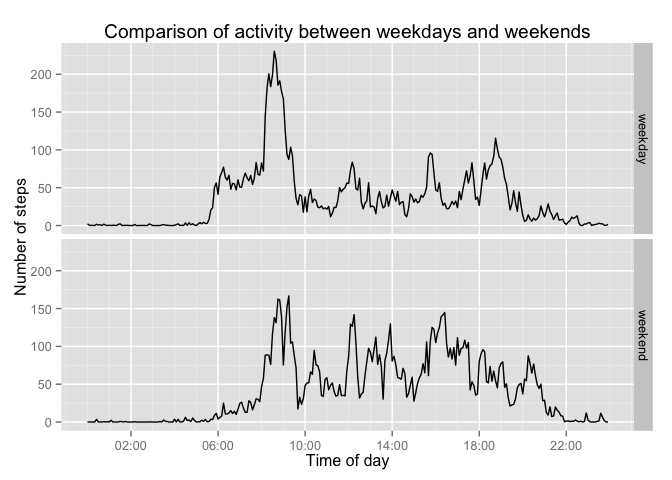

```r
g <- ggplot(by_day_type,
            aes(as.POSIXct(interval, format="%H:%M"), average_steps))

g + geom_line() +
    facet_grid(weekday_weekend ~ .) +
    scale_x_datetime(breaks = date_breaks("4 hour"),
                     minor_breaks = date_breaks("1 hour"),
                     labels=date_format("%H:%M")) +
    labs(title = "Comparison of activity between weekdays and weekends") +
    labs(x = "Time of day") +
    labs(y = "Number of steps")
```